# How Much Is Performance Worth? A Data Science Analysis of NBA Salaries

Summer 2025 Data Science Project

Ebony Dobson, Zaif Yusuf, Ahad Shah, Kashyap Kolukula

#### Contributions:

**Ahad Shah:** Worked on sections A (Project idea), B (Dataset Curation and Preprocessing), C (Exploratory Analysis), and F (Visualization, Result Analysis, Conclusion). Helped define the research questions and perform initial data wrangling, and created Method 1: Correlation Analysis with Heatmap.

**Ebony Dobson:** Focused on sections B, C, D, E, F, and G. Contributed significantly to the machine learning model development, ANOVA and t-test analysis, and assisted in finalizing the report content and layout.

**Kashyap Kolukula:** Contributed to sections B, C, and F. Helped with data preprocessing, created multiple visualizations (including violin plots and regression charts), and assisted with drawing insights from statistical methods.

**Zaif Yusuf:** Contributed to sections D, E, and F. Led the implementation and explanation of the linear regression model, including feature scaling, coefficient analysis, and realistic impact interpretation based on standardized metrics.

[Github<>](https://github.com/kashyapkolukula/CMSC320_S25_Project)

### INTRODUTION

As the NBA finals draw closer and closer, our group decided to choose a dataset that compares the National Basketball Association (NBA) player salaries. All four of us are very interested in sports and we definitely think this would be an interesting comparison to make because it’s a great opportunity to practice turning real raw data into insights. Salaries can provide an insight into teams' goals and values on the court. They can also provide information about a player's skill and value. There are many questions one can ask just from looking at salaries:

- Does player performance justify the salary these players are getting?
- How does the team’s overall spending affect their success?
- How do salaries vary by position or experience?
- What is the financial value of a player's statistical contribution?
- Which player metrics matter most for salary?
- Who are the best value players over the last 5 years?
- What does this say about how NBA teams value different skill sets?

These are all questions that can be analyzed just from looking at player statistics and their salaries. Our group is most interested in how all this data that is gathered about these players can help predict the salary of a player and also which key statistics of a player (points, all-star status, etc.) are of most importance which in turn shows what teams value.

### DATA CURATION

In this sction we will show and explain how we gathered, cleaned, and transformed raw data into structured dataframes, allowing us to analyze and draw conclusions about player statistics alongside player slaries.

We worked with two datasets that use real world datasets focused on NBA players.

**[NBA Salaries: Hoops Fortune (2020-2025)](https://www.kaggle.com/datasets/omarsobhy14/nba-players-salaries?resource=download)**

This dataset, compiled and uploaded to Kaggle, contains detailed salary information for NBA players covering the seasons from 2020 to 2025. It provides annual salary figures and player names.

**[NBA Stats (1947-present)](https://www.kaggle.com/datasets/sumitrodatta/nba-aba-baa-stats)**

These collection of datasets, also hosted on Kaggle, includes a comprehensive range of player statistics stretching from 1947 to the present. It features various performance metrics such as points per game, rebounds, assists, shooting percentages, and more.

Our team merged and titled many these two datasets to create unified tables linking player performance statistics with their corresponding salary data. These combined datasets serve as the foundation for our analyses and insights into how player performance correlates with financial compensation in the NBA.

We’ll begin by importing our datasets and preparing them for analysis. This included preprocing such as droping columns that are unused, merging dataframe together and organizing the into clean, structured formats.

```python
'''Kaggle datasts have been downloaded and can be found in "Data" folder.'''
# imports and libraries (not all may be needed)
import pandas as pd
import sqlite3
conn = sqlite3.connect("database.sqlite")
crsr = conn.cursor()
import matplotlib.pyplot as plt
import seaborn as sns
from sklearn.linear_model import LinearRegression
from sklearn.preprocessing import StandardScaler
from scipy.stats import f_oneway
import seaborn as sns
import numpy as np
from scipy.stats import ttest_rel
import torch
import torch.nn as nn
from torch.utils.data import DataLoader, TensorDataset
from sklearn.model_selection import train_test_split
from sklearn.metrics import r2_score
from sklearn.metrics import mean_absolute_error
```

```python
''' DATA PREPROCESSING: LOAD IN DATAFRAMES, DROP COLUMNS '''
# Cleaned data of unessasary colummns for better computations:

### Create df from NBA_Salaries folder
salaries_df = pd.read_csv("Data/NBA_Salaries_Hoops_Fortune_2020-2025/Nba Player Salaries.csv") # main dataset from source 1

### Create df from NBA_Stats folder
# in this tutorial will be using the following from the folder:
df_advanced = pd.read_csv("Data/NBA_Stats_1947-present/Advanced.csv") # Main df from source 2

df_player_per_game = pd.read_csv("Data/NBA_Stats_1947-present/Player Per Game.csv")

df_player_play_by_play = pd.read_csv("Data/NBA_Stats_1947-present/Player Play By Play.csv")

df_player_season_info = pd.read_csv("Data/NBA_Stats_1947-present/Player Season Info.csv")

df_player_shooting = pd.read_csv("Data/NBA_Stats_1947-present/Player Shooting.csv")

df_player_totals = pd.read_csv("Data/NBA_Stats_1947-present/Player Totals.csv")


# Clean up some unused columns we want to drop each df, if they exist
cols_to_drop = ['birth_year', 'lg', 'player_id', 'seas_id']

def drop_unwanted_columns(df, drop_cols):
    cols_in_df = [col for col in drop_cols if col in df.columns]
    return df.drop(columns=cols_in_df)
# Use definition to filter all the dataframes with a seasons column and a player name column

# filters all df
df_advanced = drop_unwanted_columns(df_advanced, ['birth_year']) # only drop one column
df_player_per_game = drop_unwanted_columns(df_player_per_game, cols_to_drop)
df_player_play_by_play = drop_unwanted_columns(df_player_play_by_play, cols_to_drop)
df_player_season_info = drop_unwanted_columns(df_player_season_info, cols_to_drop)
df_player_shooting = drop_unwanted_columns(df_player_shooting, cols_to_drop)
df_player_totals = drop_unwanted_columns(df_player_totals, cols_to_drop)

# copies of dataframes used in later analyses.
salaries_ANOVA = salaries_df.copy()
df_advanced_ANOVA = df_advanced.copy()
salaries_TTest = salaries_df[["Player Name", "2022/2023", "2023/2024"]].copy()
df_advanced_TTest = df_advanced.copy()
```

```python
salary_long = (
    salaries_df
    .melt(id_vars="Player Name",
          value_vars=["2022/2023", "2023/2024", "2024/2025"],
          var_name="Season",
          value_name="Salary")
    .replace({"Salary": r"[\$,]"}, {"Salary": ""}, regex=True)
    .assign(
        Salary=lambda d: pd.to_numeric(d["Salary"], errors="coerce"),
        player=lambda d: d["Player Name"].str.strip(),
        season=lambda d: d["Season"].str.extract(r"(\d{4})").astype(int)
    )
    .drop(columns=["Player Name"])
    .dropna(subset=["Salary"])
)
```

```python
# filter names for names matching, and seasons not between 2020-2025 (2022-2026 season) on the other dataframes
def filter_player_df(df, player_col='player', season_col='season'):
    df = df[df[player_col].isin(salary_long['player'])].copy()
    if season_col in df.columns:
        df = df[df[season_col].between(2020, 2025)]
    return df

df_player_per_game = filter_player_df(df_player_per_game)
df_player_play_by_play = filter_player_df(df_player_play_by_play)
df_player_shooting = filter_player_df(df_player_shooting)
df_player_totals = filter_player_df(df_player_totals)
df_player_season_info = filter_player_df(df_player_season_info)
```

```python
df_advanced["player"] = df_advanced["player"].str.strip()
df_advanced = df_advanced[df_advanced["lg"] == "NBA"]
df_advanced = df_advanced[df_advanced["season"].between(2020, 2025)]
```

```python
gold_df = pd.merge(
    df_advanced,
    salary_long,
    on=["player", "season"],
    how="inner"
).reset_index(drop=True)

print(gold_df.shape)
```

```
(1618, 33)
```

```python
''' DATA PROCESSING: parsing, organizing and cnverting for method 2 and method 3 '''

# Parse salaries_method2 to merge with other df's, rename player column and format yearly salary to match seasons columns
salaries_ANOVA.rename(columns={'Player Name': 'player'}, inplace=True)
# Identify season columns (years)
season_cols = [col for col in salaries_ANOVA.columns if '/' in col]
salaries_curr_format = salaries_ANOVA.melt( id_vars='player', value_vars=season_cols, var_name='year_label', value_name='salary')
# Fix the incorrect duplicate season column name
salaries_ANOVA.rename(columns={'2024/2025.1': '2025/2026'}, inplace=True)
# Convert: '2022/2023' -> 2023 and name column season to match
salaries_curr_format['season'] = salaries_curr_format['year_label'].str.extract(r'/(\d{4})')
salaries_curr_format = salaries_curr_format.dropna(subset=['season'])
salaries_curr_format['season'] = salaries_curr_format['season'].astype(int)

# Filters out names in both dataframes that do not match
salaries_ANOVA = salaries_ANOVA[salaries_ANOVA['player'].isin(df_advanced_ANOVA['player'])].copy()
df_advanced_ANOVA = df_advanced_ANOVA[df_advanced_ANOVA['player'].isin(salaries_ANOVA['player'])].copy() # since salaries are recoreded from 2020-2025, should narrow it down w/o filter
```

Once our data is preprocessed, we’ll dive into exploring its structure and key characteristics. We’ll examine how many features and records we have, check for over-represented values and look for correlations between features. This exploration will help us identify which variables are most important for deeper analysis.

Notes gathered from cleaning up the data:

- There are 5266 players total, when restricting to 2022-2026 there are 499 total players
- There are repeated player names in the advanded_df
- Advanced has the most general data
- Many columns are repeated (kaggle has better visuals)
- Many of the loaded df's can be used to create columns of players with certain characteristics
- Dropped some columns like birth year since there is more useful columns in the "advanced_df"

### EXPLORATORY ANALYSIS

In this next section, we’ll guide you through how we de-transformed and cleaned our dataframes, including additional processing steps to prepare the data for analysis.

We’ll present at least three key conclusions derived from our data, using three different statistical techniques, including hypothesis testing. Each method will help us answer important questions about player performance and salaries, and each conclusion will be supported by at least one visually compelling plot to bring our findings to life.

#### Method 1: Correlation Matrix with Heatmap Visualization

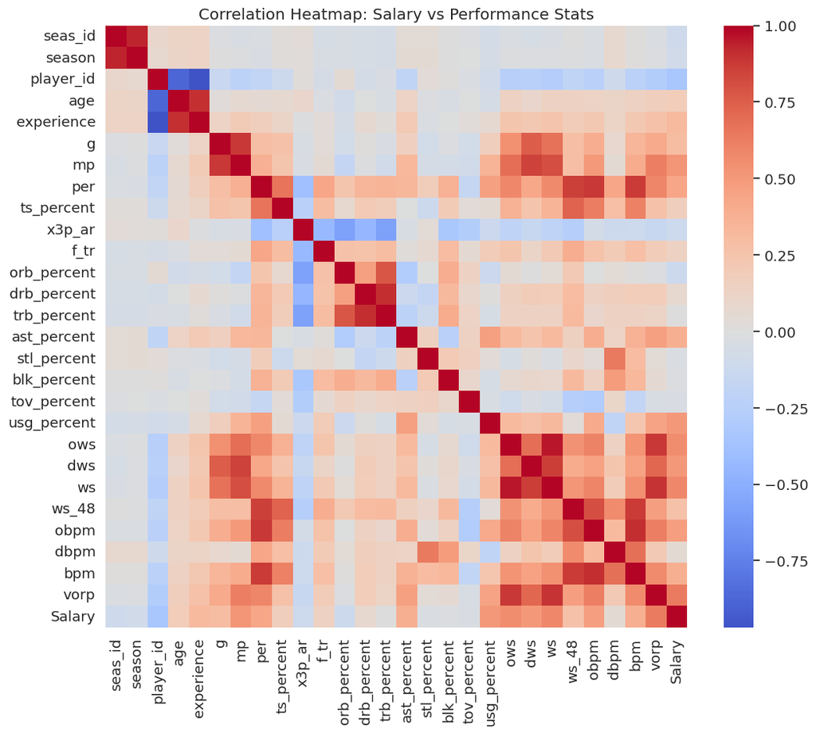

```
Salary         1.000000
vorp           0.637568
ws             0.581336
ows            0.554892
mp             0.518558
dws            0.507142
usg_percent    0.501092
obpm           0.475854
per            0.432603
bpm            0.389472
Name: Salary, dtype: float64
```

```python
correlation_matrix = gold_df.corr(numeric_only=True)

plt.figure(figsize=(12, 10))
sns.heatmap(correlation_matrix, cmap="coolwarm", center=0)
plt.title("Correlation Heatmap: Salary vs Performance Stats")
plt.show()

print(correlation_matrix["Salary"].sort_values(ascending=False).head(10))
```

#### Method 2.A: One way ANOVA test

**Question:** Is mean salary significantly different depending on position?

**Null Hypothesis:** Mean salary is not statistically significant different depending on position.

**Alternative Hypothesis:** Mean salary is statistically significant different depending on position.

```python
# Parse salaries_method2 to merge with other df's, rename player column and format yearly salary to match seasons columns
salaries_ANOVA.rename(columns={'Player Name': 'player'}, inplace=True)
# Identify season columns (years)
season_cols = [col for col in salaries_ANOVA.columns if '/' in col]
salaries_curr_format = salaries_ANOVA.melt( id_vars='player', value_vars=season_cols, var_name='year_label', value_name='salary')
# Fix the incorrect duplicate season column name
salaries_ANOVA.rename(columns={'2024/2025.1': '2025/2026'}, inplace=True)
# Convert: '2022/2023' -> 2023 and name column season to match
salaries_curr_format['season'] = salaries_curr_format['year_label'].str.extract(r'/(\d{4})')
salaries_curr_format = salaries_curr_format.dropna(subset=['season'])
salaries_curr_format['season'] = salaries_curr_format['season'].astype(int)

# Filters out names in both dataframes that do not match
salaries_ANOVA = salaries_ANOVA[salaries_ANOVA['player'].isin(df_advanced_ANOVA['player'])].copy()
df_advanced_ANOVA = df_advanced_ANOVA[df_advanced_ANOVA['player'].isin(salaries_ANOVA['player'])].copy() # since salaries are recoreded from 2020-2025, should narrow it down w/o filter
```

```
ANOVA Results:
F-statistic: 7.211
p-value: 0.000
```

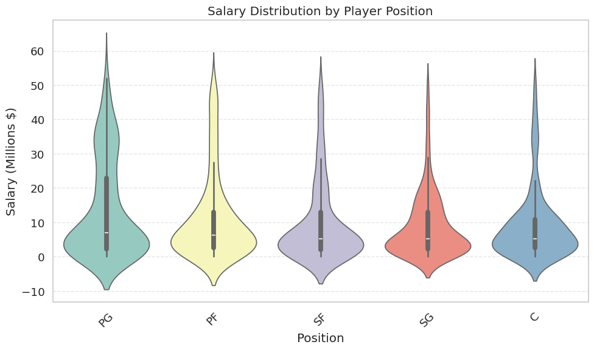

```python
salaries_curr_format['salary'] = (
    salaries_curr_format['salary']
    .replace(r'[\$,]', '', regex=True)
    .replace('', np.nan)
    .astype(float)
)

salary_with_pos = pd.merge(
    salaries_curr_format,
    df_player_season_info[['player', 'season', 'pos']],
    on=['player', 'season'],
    how='inner'
)

pure_positions = ['PG', 'SG', 'SF', 'PF', 'C']
salary_with_pos = salary_with_pos[
    (salary_with_pos['salary'] > 0) &
    (salary_with_pos['pos'].isin(pure_positions))
].copy()

salary_with_pos['salary_millions'] = salary_with_pos['salary'] / 1e6

grouped_salaries = salary_with_pos.groupby('pos')['salary'].apply(list)
anova_result = f_oneway(*grouped_salaries)

print("ANOVA Results:")
print(f"F-statistic: {anova_result.statistic:.3f}")
print(f"p-value: {anova_result.pvalue:.3f}")

plt.figure(figsize=(10, 6))
sns.violinplot(
    data=salary_with_pos,
    x="pos",
    y="salary_millions",
    hue="pos",
    legend=False,
    inner="box",
    palette="Set3"
)
plt.title("Salary Distribution by Player Position")
plt.xlabel("Position")
plt.ylabel("Salary (Millions $)")
plt.xticks(rotation=45)
plt.grid(axis='y', linestyle='--', alpha=0.5)
plt.tight_layout()
plt.show()
```

According to the One way ANOVA test done on the data, and the p-value which is less than 0.05. We can reject the null hypothesis. The violin plot also shows us the density of salaries around the boxplot of depsciptive statistics.

#### Method 2.B: T test

**H0 (null hypothesis):** There is no significant difference between the average salaries of 2022/2023 and 2023/2024

**H1 (alternative hypothesis):** There is a significant difference between the average salaries of 2022/2023 and 2023/2024.

In order to test this, a paired t-test is needed. We are only including players who have salary values for both seasons.

```python
# clean up the salary columns
salaries_TTest.columns = ["player", "2022/2023", "2023/2024"]
salaries_TTest["2022/2023"] = salaries_TTest["2022/2023"].replace(r"[\$,]", "", regex=True).astype(float)
salaries_TTest["2023/2024"] = salaries_TTest["2023/2024"].replace(r"[\$,]", "", regex=True).astype(float)

# drop rows iwth missing or zero salaries for either year
paired_df = salaries_TTest[(salaries_TTest["2022/2023"] > 0) & (salaries_TTest["2023/2024"] > 0)].copy()

# perform paired t-test (ttest_rel performs a t-test on two related samples ttest_rel(a, b))

t_stat, p_val = ttest_rel(paired_df['2022/2023'], paired_df['2023/2024'])
print(f"Paired T-Test Results:")
print(f"T-statistic: {t_stat}")
print(f"P-value: {p_val}")

# Conclusion
alpha = 0.05
if p_val < alpha:
    print("Reject the null hypothesis: Salaries changed significantly.")
else:
    print("Fail to reject the null hypothesis: No significant salary change.")
```

```
Paired T-Test Results:
T-statistic: -6.835436760690918
P-value: 2.991643065086199e-11
Reject the null hypothesis: Salaries changed significantly.
```

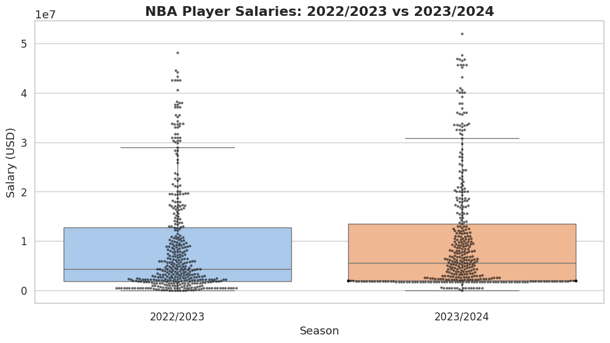

```python
# Step 1: Create a clean DataFrame with both seasons
salary_long_TTest = paired_df[["player", "2022/2023", "2023/2024"]].melt(
    id_vars="player",
    value_vars=["2022/2023", "2023/2024"],
    var_name="Season",
    value_name="Salary"
)

# Step 2: Set the plot style
sns.set(style="whitegrid", font_scale=1.2)

# Step 3: Create the plot
plt.figure(figsize=(12, 6))
sns.boxplot(x='Season', y='Salary', data=salary_long_TTest, hue='Season', palette='pastel', showfliers=False, legend=False) # added "hue='Season'," and " legend=False" to remove warning
sns.swarmplot(x='Season', y='Salary', data=salary_long_TTest, color='black', alpha=0.6, size=3) # changed size to 3 not 4 to fix second waring

# Step 4: Customize titles and labels
plt.title("NBA Player Salaries: 2022/2023 vs 2023/2024", fontsize=16, fontweight="bold")
plt.ylabel("Salary (USD)", fontsize=13)
plt.xlabel("Season", fontsize=13)
plt.xticks(fontsize=12)
plt.yticks(fontsize=12)


# Step 5: Show the plot
plt.show()
```

This box and whisker plots above compares the salaries of the players for seasons 2022/2023 with 2023/2024. The swarmplot shows every individual player’s salary as a point. You can clearly see the median, IQR, and the overall distribution of the salaries for both seasons. If the boxes shift significantly up or down between seasons, it suggests that there is a change in salary levels. Additionally, as you can see there are very high outliers for both seasons..

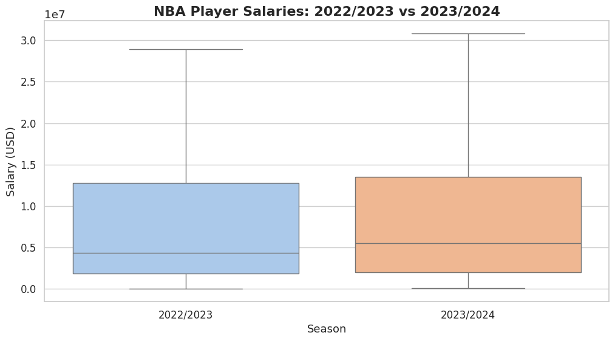

```python
# Step 3: Create the plot without the points
plt.figure(figsize=(12, 6))
sns.boxplot(x='Season', y='Salary', data=salary_long_TTest, hue='Season', palette='pastel', showfliers=False, legend=False) # added legend and hue here too


# Step 4: Customize titles and labels
plt.title('NBA Player Salaries: 2022/2023 vs 2023/2024', fontsize=16, fontweight='bold')
plt.ylabel('Salary (USD)', fontsize=13)
plt.xlabel('Season', fontsize=13)
plt.xticks(fontsize=12)
plt.yticks(fontsize=12)


# Step 5: Show the plot
plt.show()
```

#### Method 3: Linear Regression Model with Scatter plots AND Bar plots of coefficients

**Coeffiecient Plot:** Does Performance Predict Salary?

Coeffiecient plots can be used to visualize the weights that are assigned to a variable. In this case a positive coeffiecient show that an increase in that variable will increase salary, where a negative coeffiecient shows a decrease in salary as the variable increases. Neither positve or negative (zero coeffiecients) show there is no impact on the salary.

**Regression Models:**

- Is Age Related to Salary?
- Is Experience Related to Salary?
- Is salary proportional to minutes played?

A regression model fits a “line” (or hyperplane) that best predicts a numeric outcome (like salary) from one or more variables. Positve slopes shows in this case salary increases as the variable increases, and negative slopes show that as a variable incrases salary decreases.

Starting with our coeffiecient plot, it answers the question: "*Does Performance Predict Salary?*"

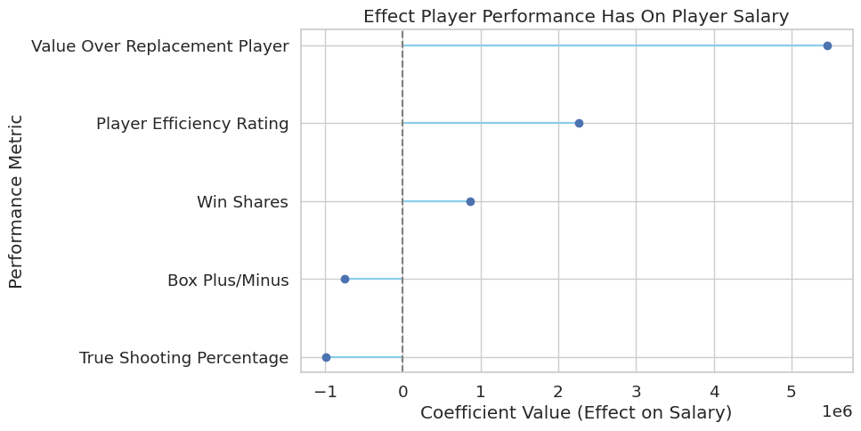

```
Win Shares: 1 SD change (2.4) → $2,103,947 (28.8% of avg salary)
Value Over Replacement Player: 1 SD change (1.1) → $6,077,465 (83.1% of avg salary)
Box Plus/Minus: 1 SD change (4.3) → $-3,239,977 (-44.3% of avg salary)
Player Efficiency Rating: 1 SD change (5.6) → $12,592,377 (172.1% of avg salary)
True Shooting Percentage: 1 SD change (0.1) → $-104,229 (-1.4% of avg salary)
```

```python
# Does Performance Predict Salary?
df_cleaned = gold_df[['ws', 'vorp', 'bpm', 'per', 'ts_percent', 'Salary']].dropna()

X = df_cleaned[['ws', 'vorp', 'bpm', 'per', 'ts_percent']].rename(columns={
    'ws': 'Win Shares',
    'vorp': 'Value Over Replacement Player',
    'bpm': 'Box Plus/Minus',
    'per': 'Player Efficiency Rating',
    'ts_percent': 'True Shooting Percentage'
})

y = df_cleaned['Salary']


model = LinearRegression()
model.fit(X, y)

scaler = StandardScaler()
X_scaled = scaler.fit_transform(X)
model.fit(X_scaled, y)
std_coefs = pd.Series(model.coef_, index=X.columns)

coefs_sorted = std_coefs.sort_values()

plt.figure(figsize=(8,5))
plt.hlines(y=coefs_sorted.index, xmin=0, xmax=coefs_sorted.values, color="skyblue")
plt.plot(coefs_sorted.values, coefs_sorted.index, "o")
plt.axvline(0, color="grey", linestyle="--")
plt.title("Effect Player Performance Has On Player Salary")
plt.xlabel("Coefficient Value (Effect on Salary)")
plt.ylabel("Performance Metric")
plt.show()

general_change = std_coefs.copy()

mean_salary = y.mean()
for metric in general_change.index:
    realistic_change = X[metric].std()  # Using 1 standard deviation change
    dollar_impact = general_change[metric] * realistic_change
    pct_impact = (dollar_impact / mean_salary) * 100
    print(f"{metric}: 1 SD change ({realistic_change:.1f}) → ${dollar_impact:,.0f} ({pct_impact:.1f}% of avg salary)")

change = general_change * X.std()
change = change.sort_values()
```

Overall, performance metrics show a significant impact on salary, though not all in the same direction:

**Conclusion:** Key performance metrics like PER and VORP strongly predict higher salaries, while some advanced stats like Box Plus/Minus show unexpected negative relationships, warranting further exploration.

Next, this regression models will answer the question: "*Is Age Related to Salary?*"

Younger players may earn less due to rookie contracts, while veteran players might command higher salaries—or decline due to age. Here, we model the relationship between age and salary to determine if there’s a clear trend, visualized with scatter plots and a regression line.

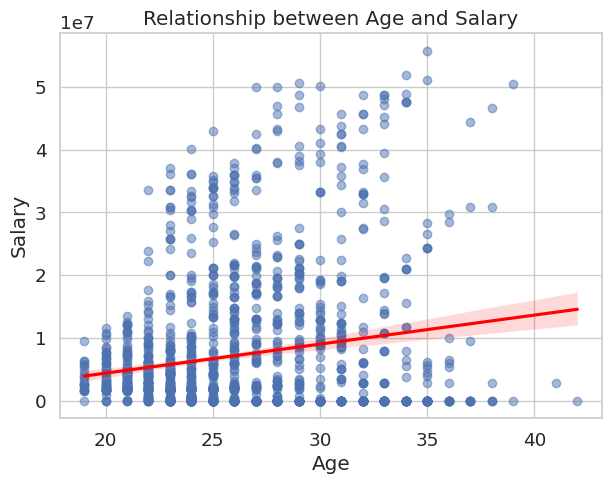

```python
# Is Age Related to Salary?
age_salary = gold_df.dropna(subset=["age", "Salary"])

plt.figure(figsize=(7,5))
sns.regplot(
    data=age_salary,
    x="age",
    y="Salary",
    scatter_kws={"alpha":0.5},
    line_kws={"color":"red"}
)
plt.title("Relationship between Age and Salary")
plt.xlabel("Age")
plt.ylabel("Salary")
plt.show()
```

There’s a slight positive relationship between age and salary. The regression line slopes upward, indicating older players tend to earn more, possibly reflecting accrued experience, veteran contracts, or established reputations.

However, the spread of data widens significantly for players above ~30 years old, suggesting high salary variance among veterans. Some older players still earn low salaries, perhaps due to declining performance, injuries, or minimum contracts.

**Conclusion:** Age modestly predicts higher salary, but variability increases as players age, showing that veteran status alone isn’t a guarantee of high pay.

This next regression model answers: "*Is Experience Related to Salary?*"

This analysis tests whether years of NBA experience correlate with higher salaries. Do veteran players consistently earn more, or is the relationship less predictable? A regression plot shows the strength and direction of the trend.

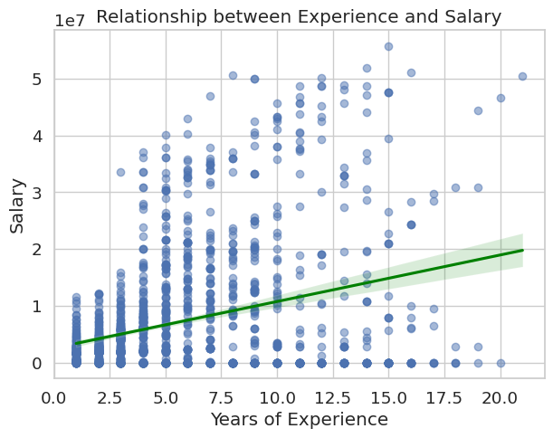

```python
# Is Experience Related to Salary?
exp_df = df_player_totals.merge(
    salary_long,
    on=["player", "season"],
    how="inner"
).dropna(subset=["experience", "Salary"])

plt.figure(figsize=(7,5))
sns.regplot(
    data=exp_df,
    x="experience",
    y="Salary",
    scatter_kws={"alpha":0.5},
    line_kws={"color":"green"}
)
plt.title("Relationship between Experience and Salary")
plt.xlabel("Years of Experience")
plt.ylabel("Salary")
plt.show()
```

Years of experience show a clearer positive relationship with salary than age. The regression trend suggests salaries generally rise as players accumulate seasons in the NBA.

These last regression model will answer both: "*Is salary proportional to minutes played?*" and "*Is salary proportional to minutes per game?*"

Playing time is often a proxy for value: coaches allocate more minutes to their best players. We analyze whether salary scales proportionally with minutes played per game, using scatter plots to check linearity and a regression model to quantify the relationship.

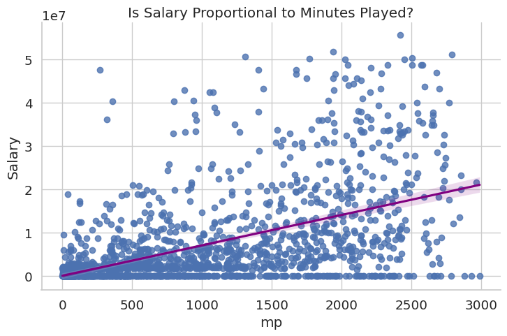

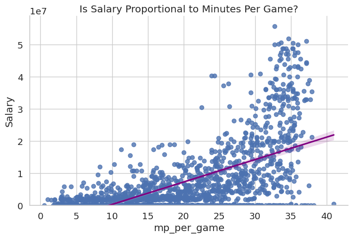

```python
# Is salary proportional to minutes played?

sns.lmplot(data=gold_df, x='mp', y='Salary', height=5, aspect=1.5, line_kws={"color":"purple"})
plt.title("Is Salary Proportional to Minutes Played?")
plt.show()

# Merge per-game with salary
mp_df = df_player_per_game.merge(
    salary_long, on=['player', 'season'], how='inner'
)

sns.lmplot(data=mp_df, x='mp_per_game', y='Salary', height=5, aspect=1.5, line_kws={"color":"purple"})
plt.ylim(-0.05, None)   # Force y-axis lower bound to -0.05
plt.title("Is Salary Proportional to Minutes Per Game?")
plt.show()
```

Both plots show a positive relationship between playing time and salary:

Total minutes played and salary are clearly correlated—players logging more minutes earn higher salaries, reflecting their value and importance to their teams.

Minutes per game also correlate with higher pay, but the scatter shows greater variance. While stars playing 30+ minutes per game typically earn more, there are clusters of lower-paid players averaging high minutes, suggesting specific team situations or contract structures.

**Conclusion:** Playing time is a significant predictor of salary. Coaches allocate more minutes to their most trusted players, and the data confirms those players are financially rewarded.

#### PRIMARY ANALYSIS + VISUALIZATION

Can we predict NBA salaries from player stats, and learn which stats matter most?

Regression is definitely the most appropriate machine learning model for our goal. We are trying to predict what an NBA player should be paid and a player’s salary is a continuous numerical value. Regression tasks are usually designed for output variables that are quantitative like dollar amount. Additionally, we are not categorizing players into salary brackets, which would be more classification and we are not grouping them based on similarities, which would be clustering. Instead, we are estimating a salary amount based on their features.

- Salary is a continuous numeric target variable.
- We wanted interpretability to understand which player statistics have the most financial impact.
- Linear regression allows us to quantify the effect of each metric on salary, answering our core question: Does player performance justify salary?
- Our results indicate that metrics like PER and VORP significantly increase predicted salary, while others like BPM showed unexpected negative coefficients, suggesting complex dynamics in NBA contracts.

We can start by prepariing the Data Loaders, test_lader and train_loader. We will use test_train_split to split the data and then normalize it to make a zero mean and unit vairance. Taking the dataframe, 'df_cleaned' from method 3 above, we can implement an MLP to predict the salary of a given player.

```python
# Using 'df_cleaned' from the coeff plot in method 3.

# normalize y to a better range of numbers so MSE is not off ( without it, the loss curve shows that the MLPmagnitudeis too high due to the large scale of salaries.)
new_y = df_cleaned['Salary'] / 1e6
# split data
X_train, X_test, y_train, y_test = train_test_split(X, new_y, test_size=0.2, random_state=42)

X_train_scaled = scaler.fit_transform(X_train)
X_test_scaled = scaler.transform(X_test)

# convert to float tensors
X_train_tensor = torch.FloatTensor(X_train_scaled)
y_train_tensor = torch.FloatTensor(y_train.values).view(-1, 1)

X_test_tensor = torch.FloatTensor(X_test_scaled)
y_test_tensor = torch.FloatTensor(y_test.values).view(-1, 1)

# Create datasets
train_dataset = TensorDataset(X_train_tensor, y_train_tensor)
test_dataset = TensorDataset(X_test_tensor, y_test_tensor)

batch_size = 32

# Create DataLoaders
train_loader = DataLoader(train_dataset, batch_size=batch_size, shuffle=True)
test_loader = DataLoader(test_dataset, batch_size=batch_size, shuffle=False)

# Extra info if needed:
batch_size = train_loader.batch_size
num_train_data = len(train_loader) * batch_size
num_test_data = len(test_loader) * batch_size
feat_dim = train_loader.dataset[0][0].shape[0]
```

Next we will implement the MLP with layers and relu activation

```python
class MLPModel(nn.Module):
    def __init__(self, input_dim):
        super(MLPModel, self).__init__()
        self.layer1 = nn.Linear(input_dim, 64)
        self.layer2 = nn.Linear(64, 32)
        self.output = nn.Linear(32, 1)

    def forward(self, x):
        x = torch.relu(self.layer1(x))
        x = torch.relu(self.layer2(x))
        x = self.output(x)
        return x

model = MLPModel(input_dim=feat_dim)
```

Next we create a loss function and optimizer, then train the model using epochs

```python
criterion = nn.MSELoss()
optimizer = torch.optim.Adam(model.parameters(), lr=0.001)

epochs = 100

batch_losses = []
epoch_losses = []

train_r2_scores = []
validate_r2_scores = []

for epoch in range(epochs):
    running_loss = 0.0
    for data, targets in train_loader:
        optimizer.zero_grad()
        outputs = model(data)
        loss = criterion(outputs, targets)
        loss.backward()
        optimizer.step()

        batch_losses.append(loss.item())
        running_loss += loss.item()

    avg_loss = running_loss / len(train_loader)
    epoch_losses.append(avg_loss)

    # calculate R2 each epoch
    model.eval()
    with torch.no_grad():
        train_preds = model(X_train_tensor)
        r2_train = r2_score(y_train_tensor.numpy(), train_preds.numpy())

        test_preds = model(X_test_tensor)
        r2_val = r2_score(y_test_tensor.numpy(), test_preds.numpy())

        train_r2_scores.append(r2_train)
        validate_r2_scores.append(r2_val)
    model.train()

    print(f"Epoch [{epoch+1}/{epochs}] - Avg Loss: {avg_loss:.4f} - "
          f"Train R2: {r2_train:.4f} - Val R2: {r2_val:.4f}")
```

```
Epoch [1/100] - Avg Loss: 160.5860 - Train R2: -0.2865 - Val R2: -0.2497
Epoch [2/100] - Avg Loss: 127.2224 - Train R2: 0.1082 - Val R2: 0.1511
Epoch [3/100] - Avg Loss: 84.1914 - Train R2: 0.3255 - Val R2: 0.4332
Epoch [4/100] - Avg Loss: 75.2280 - Train R2: 0.3454 - Val R2: 0.4536
Epoch [5/100] - Avg Loss: 72.4879 - Train R2: 0.3598 - Val R2: 0.4579
Epoch [6/100] - Avg Loss: 72.5529 - Train R2: 0.3721 - Val R2: 0.4721
Epoch [7/100] - Avg Loss: 69.9971 - Train R2: 0.3807 - Val R2: 0.4692
Epoch [8/100] - Avg Loss: 70.5336 - Train R2: 0.3893 - Val R2: 0.4808
Epoch [9/100] - Avg Loss: 70.1129 - Train R2: 0.3963 - Val R2: 0.4872
Epoch [10/100] - Avg Loss: 67.3234 - Train R2: 0.3986 - Val R2: 0.4728
Epoch [11/100] - Avg Loss: 68.1461 - Train R2: 0.4046 - Val R2: 0.4795
Epoch [12/100] - Avg Loss: 69.6620 - Train R2: 0.4111 - Val R2: 0.4934
Epoch [13/100] - Avg Loss: 66.7050 - Train R2: 0.4138 - Val R2: 0.4829
Epoch [14/100] - Avg Loss: 65.6228 - Train R2: 0.4182 - Val R2: 0.4892
Epoch [15/100] - Avg Loss: 65.5311 - Train R2: 0.4217 - Val R2: 0.4926
Epoch [16/100] - Avg Loss: 65.8541 - Train R2: 0.4241 - Val R2: 0.4964
Epoch [17/100] - Avg Loss: 65.7434 - Train R2: 0.4269 - Val R2: 0.4968
Epoch [18/100] - Avg Loss: 68.7798 - Train R2: 0.4290 - Val R2: 0.4987
Epoch [19/100] - Avg Loss: 67.2869 - Train R2: 0.4323 - Val R2: 0.4925
Epoch [20/100] - Avg Loss: 63.8500 - Train R2: 0.4350 - Val R2: 0.4986
Epoch [21/100] - Avg Loss: 63.9387 - Train R2: 0.4359 - Val R2: 0.4844
Epoch [22/100] - Avg Loss: 62.8377 - Train R2: 0.4376 - Val R2: 0.4823
Epoch [23/100] - Avg Loss: 63.7653 - Train R2: 0.4419 - Val R2: 0.4961
Epoch [24/100] - Avg Loss: 63.3042 - Train R2: 0.4388 - Val R2: 0.4739
Epoch [25/100] - Avg Loss: 63.5258 - Train R2: 0.4441 - Val R2: 0.4992
Epoch [26/100] - Avg Loss: 62.4057 - Train R2: 0.4480 - Val R2: 0.4947
Epoch [27/100] - Avg Loss: 61.7202 - Train R2: 0.4496 - Val R2: 0.4884
Epoch [28/100] - Avg Loss: 63.0982 - Train R2: 0.4516 - Val R2: 0.4892
Epoch [29/100] - Avg Loss: 62.3321 - Train R2: 0.4536 - Val R2: 0.4928
Epoch [30/100] - Avg Loss: 64.3367 - Train R2: 0.4508 - Val R2: 0.5010
Epoch [31/100] - Avg Loss: 61.6109 - Train R2: 0.4560 - Val R2: 0.4871
Epoch [32/100] - Avg Loss: 61.0580 - Train R2: 0.4553 - Val R2: 0.4765
Epoch [33/100] - Avg Loss: 65.4637 - Train R2: 0.4585 - Val R2: 0.4969
Epoch [34/100] - Avg Loss: 60.8316 - Train R2: 0.4525 - Val R2: 0.4632
Epoch [35/100] - Avg Loss: 61.2144 - Train R2: 0.4614 - Val R2: 0.4865
Epoch [36/100] - Avg Loss: 60.6338 - Train R2: 0.4628 - Val R2: 0.4944
Epoch [37/100] - Avg Loss: 60.8273 - Train R2: 0.4615 - Val R2: 0.4775
Epoch [38/100] - Avg Loss: 65.7289 - Train R2: 0.4648 - Val R2: 0.4952
Epoch [39/100] - Avg Loss: 60.9248 - Train R2: 0.4648 - Val R2: 0.4798
Epoch [40/100] - Avg Loss: 61.5219 - Train R2: 0.4664 - Val R2: 0.4796
```

[output cut: 45 more lines]

```
Epoch [86/100] - Avg Loss: 58.4017 - Train R2: 0.4923 - Val R2: 0.5095
Epoch [87/100] - Avg Loss: 57.0760 - Train R2: 0.4969 - Val R2: 0.5027
Epoch [88/100] - Avg Loss: 56.4474 - Train R2: 0.4959 - Val R2: 0.5086
Epoch [89/100] - Avg Loss: 56.5703 - Train R2: 0.4929 - Val R2: 0.4814
Epoch [90/100] - Avg Loss: 56.5562 - Train R2: 0.4959 - Val R2: 0.5105
Epoch [91/100] - Avg Loss: 57.6988 - Train R2: 0.4985 - Val R2: 0.5056
Epoch [92/100] - Avg Loss: 56.9966 - Train R2: 0.4980 - Val R2: 0.5073
Epoch [93/100] - Avg Loss: 56.4852 - Train R2: 0.4990 - Val R2: 0.5016
Epoch [94/100] - Avg Loss: 56.6320 - Train R2: 0.4974 - Val R2: 0.4897
Epoch [95/100] - Avg Loss: 56.2667 - Train R2: 0.4958 - Val R2: 0.5108
Epoch [96/100] - Avg Loss: 58.2939 - Train R2: 0.5002 - Val R2: 0.5040
Epoch [97/100] - Avg Loss: 57.7469 - Train R2: 0.4879 - Val R2: 0.4691
Epoch [98/100] - Avg Loss: 56.6979 - Train R2: 0.5013 - Val R2: 0.4976
Epoch [99/100] - Avg Loss: 56.2016 - Train R2: 0.4991 - Val R2: 0.4897
Epoch [100/100] - Avg Loss: 58.1296 - Train R2: 0.5014 - Val R2: 0.4936
```

```python
# evaluate test loss after training
model.eval()
test_loss = 0.0
with torch.no_grad():
    for data, targets in test_loader:
        outputs = model(data)
        loss = criterion(outputs, targets)
        test_loss += loss.item()

avg_test_loss = test_loss / len(test_loader)
print("Test Loss (MSE):", avg_test_loss)
```

```
Test Loss (MSE): 63.035573265769266
```

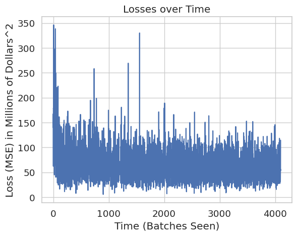

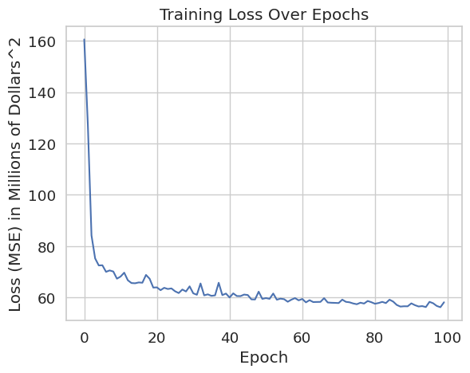

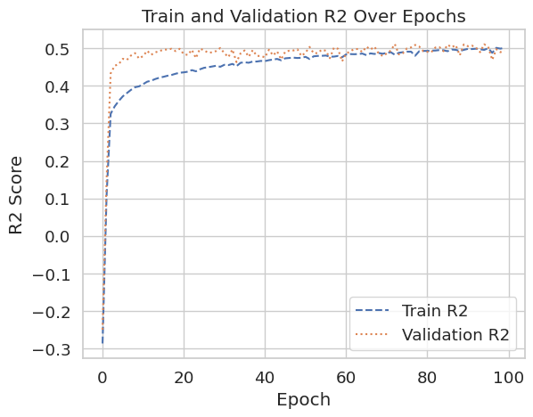

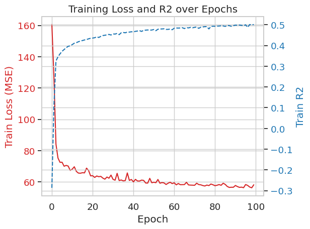

```python
# Plot

plt.plot(batch_losses)
plt.title("Losses over Time")
plt.xlabel("Time (Batches Seen)")
plt.ylabel("Loss (MSE) in Millions of Dollars^2")
plt.show()

plt.plot(epoch_losses)
plt.title("Training Loss Over Epochs")
plt.xlabel("Epoch")
plt.ylabel("Loss (MSE) in Millions of Dollars^2")
plt.show()

plt.plot(range(epochs), train_r2_scores, label='Train R2', linestyle='--')
plt.plot(range(epochs), validate_r2_scores, label='Validation R2', linestyle=':')
plt.xlabel('Epoch')
plt.ylabel('R2 Score')
plt.title('Train and Validation R2 Over Epochs')
plt.legend()
plt.show()

fig, ax1 = plt.subplots()

color = 'tab:red'
ax1.set_xlabel('Epoch')
ax1.set_ylabel('Train Loss (MSE)', color=color)
ax1.plot(range(epochs), epoch_losses, color=color, label='Train Loss')
ax1.tick_params(axis='y', labelcolor=color)

ax2 = ax1.twinx()
color = 'tab:blue'
ax2.set_ylabel('Train R2', color=color)
ax2.plot(range(epochs), train_r2_scores, color=color, linestyle='--', label='Train R2')
ax2.tick_params(axis='y', labelcolor=color)

plt.title("Training Loss and R2 over Epochs")
fig.tight_layout()
plt.show()
```

Lastly, we can make out predictions using our train and test sets.

```python
with torch.no_grad():
    y_train_pred = model(X_train_tensor)
    y_test_pred = model(X_test_tensor)

# convert predictions back to numpy for analysis
y_test_pred_np = y_test_pred.numpy().flatten()
print(y_test_pred_np[0:30]) # print first 30 predictions
```

```
[ 5.6945806  5.8713393  7.9243727  6.4277925 25.440065   4.712335
  4.089259  31.332323   1.4259261 24.925861   9.140352   1.6982328
  2.924098   3.5452728  7.868337   4.994285   7.1053195 21.880064
  6.4885726 12.685443   3.672525   3.08211    6.6034765  2.2568636
  3.576067   9.2894125  3.0667028  3.8221474 10.131384   3.2648864]
```

#### INSIGHT & CONCLUSION

Looking at the loss plot, we can see that because the graph is decreasing over time, the model is learning how to predict NBA salaries. The MLP was trained to predict NBA salaries based on player statistics, with training loss measured via Mean Squared Error (MSE) (per millions).

As the model trains, it’s getting better at learning how NBA player stats relate to salaries. Early on, its predictions were way off. But the average prediction error has dropped significantly over time, suggesting the MLP is indeed capturing meaningful patterns between player performance and salary.

Unlike linear regression, the MLP does not produce direct coefficients explaining how much each stat contributes to salary. However, it offers a flexible alternative for pure predictive accuracy.

Taking in account of our regression models and and this MLP we can say that an NBA players stats do leave an impact on their pay in various ways, both positive and negative, given by the results of or regression models. The multiple linear regression shows that player stats do have a learnable relationship to salary and that it is possible for the model to predict a players salary given enough time.

The R2 train and validation curves provide some insight as well. Like the loss curve, it starts out poor and over time imporved as training progressed confiming the MLP was learning meaningful patterns from the data. The close alignment between training and validation R2 suggests the MLP generalizes well and is not overfitting.

```
Test MAE (millions): 5.5694
```

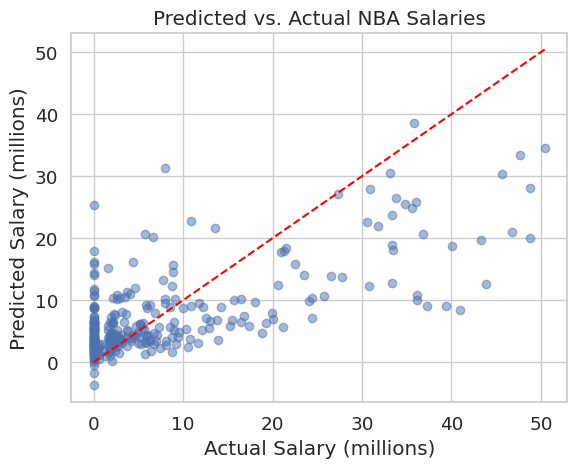

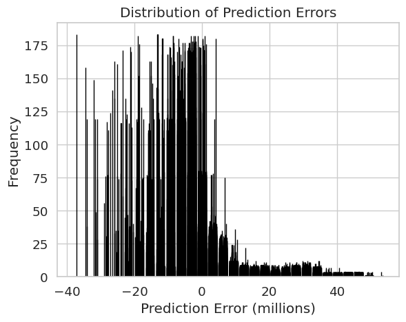

```python
# Mean absolute error:
mae = mean_absolute_error(y_test_tensor.numpy(), y_test_pred_np)
print(f"Test MAE (millions): {mae:.4f}")

# Plot to compare predicted vs actual
plt.scatter(y_test_tensor.numpy(), y_test_pred_np, alpha=0.5)
plt.plot([0, y_test_tensor.max()], [0, y_test_tensor.max()], color='red', linestyle='--')
plt.xlabel("Actual Salary (millions)")
plt.ylabel("Predicted Salary (millions)")
plt.title("Predicted vs. Actual NBA Salaries")
plt.show()

# Plot to check error frequencies
errors = y_test_tensor.numpy() - y_test_pred_np
plt.hist(errors, bins=30, edgecolor='black')
plt.xlabel("Prediction Error (millions)")
plt.ylabel("Frequency")
plt.title("Distribution of Prediction Errors")
plt.show()
```